# Cervejaria Consumo Mensal Cerveja

Marcio Cruz

29/06/2021

## Case

Uma cervejaria deseja iniciar comercialização de uma das marcas de sua cerveja premium em uma cidade no interior de São Paulo. Para isso, ela deseja projetar qual será o consumo mensal de cerveja (em litros) nesta cidade, com base em características de outras cidades do Estado. Cada linha da base de dados representa uma cidade.

## Respostas

### a) Calcule o coeficiente de correlação entre as variáveis quantitativas do banco de dados. Interprete os coeficientes.

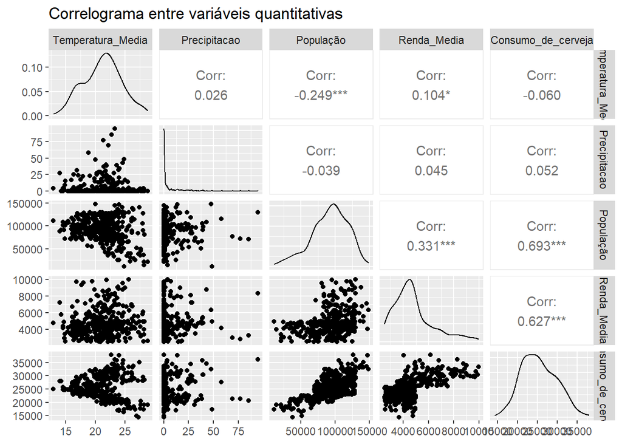

**Interpretação:**De acordo com os valores o consumo mensal de cerveja são explicados pelas variáveis da população e renda média.

### b) Realize a análise bidimensional entre as covariáveis existentes e investigue possíveis problemas de multicolinearidade.

Não há problemas entre colinearidades. Inclusive as covariantes mais imporantes, que são a População e a Renda Média possui uma correlação baixa entre si.

### c) Obtenha o modelo de regressão linear múltipla, considerando um nível de significância de 10% para seleção de variáveis.

```r
regressao.1 <- lm(data=cerveja, cerveja$Consumo_de_cerveja ~ cerveja$Temperatura_Media + cerveja$Precipitacao + cerveja$População + cerveja$Renda_Media)
summary(regressao.1)
```

```
##
## Call:
## lm(formula = cerveja$Consumo_de_cerveja ~ cerveja$Temperatura_Media +
##     cerveja$Precipitacao + cerveja$População + cerveja$Renda_Media,
##     data = cerveja)
##
## Residuals:
##     Min      1Q  Median      3Q     Max
## -6909.3 -1792.0   -74.8  1544.5  7796.8
##
## Coefficients:
##                               Estimate   Std. Error t value            Pr(>|t|)
## (Intercept)               10153.345034  1162.055737   8.737 <0.0000000000000002
## cerveja$Temperatura_Media    44.824204    44.880922   0.999              0.3186
## cerveja$Precipitacao         18.754592    10.913367   1.718              0.0866
## cerveja$População             0.092286     0.005663  16.297 <0.0000000000000002
## cerveja$Renda_Media           1.202680     0.092088  13.060 <0.0000000000000002
##
## (Intercept)               ***
## cerveja$Temperatura_Media
## cerveja$Precipitacao      .
## cerveja$População         ***
## cerveja$Renda_Media       ***
## ---
## Signif. codes:  0 '***' 0.001 '**' 0.01 '*' 0.05 '.' 0.1 ' ' 1
##
## Residual standard error: 2577 on 357 degrees of freedom
## Multiple R-squared:  0.6612, Adjusted R-squared:  0.6575
## F-statistic: 174.2 on 4 and 357 DF,  p-value: < 0.00000000000000022
```